# Modeling and prediction for movies

## Setup

### Load packages

```r
library(ggplot2)
library(dplyr)
library(statsr)
library(ggthemes)
```

### Load data

Make sure your data and R Markdown files are in the same directory. When loaded your data file will be called `movies`. Delete this note when before you submit your work.

```r
load("movies.Rdata")
```

## Part 1: Data

The data set is from an observational study with information on a random sample of movies released in theaters betweewn 1970 and 2014. The information sources are Rotten Tomatoes and IMDB Web sites. Both are well-known movie information aggregators with data on a large volume of movies.

While the data set sampling from the site is listed as random sampling, audience scores for specific movies on the sites are not randomly selected. Scores are entered by visitors to the Web sites. The audience raters are self-selected so the sample may be biased toward moviegoers who frequent these specific sites, who had a strong positive or negative reactions, movie buffs and younger people who spend more time on the Web. As such causality and genearalizability cannot be inferred.

Furthermore, there is no guarantee the audience raters actually watched the movie. They could be fans of the cast in a positive or negative way. Or they could be affiliates of the movie studio seeking to promote the film (or of a rival studio seeking to lower attendance).

## Part 2: Research question

I am a keen movie buff who worked briefly in the industry after college so anything related to movies is fascinating for me!

For this specfic project, I am interested to learn what factors have significant correlations with overall audience appreciation for a movie. Audience_score will be the response variable, albeit with limitations described in part 1.

One hypothetized predictive factor is whether average critic ratings (critic_rating) has an association with average audience score. Critics’ opinions influence my interest in seeing a movie and I am curious whether similar with the overall audience in the study.

Another study predictivre factor will be genre. Audiences’ like of a movie may be partially driven by the genre itself. For example, someone who dislikes horror movies or musicals may dislike all such films all else equal.

The final study predictive factor will be MPAA rating. Audiences’ like of a movie may be partially driven by the MPAA rating. For example, someone offended by sex or violent scenes in an R movie may dislike all such films all else equal.

## Part 3: Exploratory data analysis

```r
movies %>%
  group_by (genre) %>%
  na.exclude() %>%
  summarize (med=median (audience_score), sd = sd (audience_score), n = n ()) %>%
  mutate_if (is.numeric, round, 1) %>%
  arrange (-med)
```

```
## # A tibble: 11 x 4
##    genre                       med    sd     n
##    <fct>                     <dbl> <dbl> <dbl>
##  1 Documentary                86     8.5    40
##  2 Musical & Performing Arts  80.5  11.4    12
##  3 Other                      74    18.5    15
##  4 Art House & International  71    13.6    12
##  5 Drama                      70    18.6   298
##  6 Animation                  67.5  21       8
##  7 Science Fiction & Fantasy  53    25.8     8
##  8 Action & Adventure         51.5  20      62
##  9 Mystery & Suspense         51.5  19.3    56
## 10 Comedy                     49.5  19.2    86
## 11 Horror                     42    16.5    22
```

```r
movies %>%
  group_by (mpaa_rating) %>%
  na.exclude() %>%
  summarize (med=median (audience_score), sd = sd (audience_score), n = n ()) %>%
  mutate_if (is.numeric, round, 1) %>%
  arrange (-med)
```

```
## # A tibble: 6 x 4
##   mpaa_rating   med    sd     n
##   <fct>       <dbl> <dbl> <dbl>
## 1 Unrated        82  15.8    41
## 2 G              77  20.9    16
## 3 NC-17          71  NA       1
## 4 PG             65  20     111
## 5 R              65  20.1   319
## 6 PG-13          56  19.2   131
```

```r
movies %>%
  group_by (critics_rating) %>%
  na.exclude () %>%
  summarize (med=median (audience_score), sd = sd (audience_score), n = n ()) %>%
  mutate_if (is.numeric, round, 1) %>%
  arrange (-med)
```

```
## # A tibble: 3 x 4
##   critics_rating    med    sd     n
##   <fct>           <dbl> <dbl> <dbl>
## 1 Certified Fresh    81  11.2   131
## 2 Fresh              73  15.7   195
## 3 Rotten             48  17.7   293
```

Median audience rating by critics rating ranges from 48 to 81 so average critic rating seems to be a possible audience score predictor variable. This implies may be correlation between how critics like a movie and how the general population likes the same movie. Standard deviation is also materially different by group as ranges from 11 to 18.

```r
movies %>%
  group_by (thtr_rel_month) %>%
  na.exclude() %>%
  summarize (med=median (audience_score), sd = sd (audience_score), n = n ()) %>%
  mutate_if (is.numeric, round, 1) %>%
  arrange (-med)
```

```
## # A tibble: 12 x 4
##    thtr_rel_month   med    sd     n
##             <dbl> <dbl> <dbl> <dbl>
##  1             12  71.5  19.5    66
##  2              7  68    20.2    45
##  3             11  67.5  19.2    48
##  4              2  67    20.1    32
##  5              6  66    20.5    71
##  6             10  66    21.6    65
##  7              4  65    20.9    43
##  8              9  64    22.7    51
##  9              8  63.5  18.2    42
## 10              1  63    19      64
## 11              5  63    20.9    43
## 12              3  61    19.5    49
```

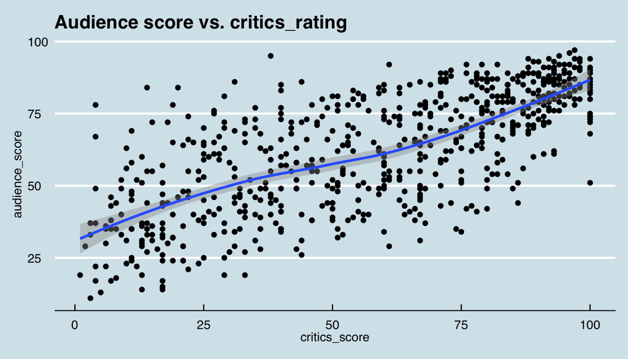

```r
movies %>%
  ggplot (aes (x=critics_score, y=audience_score)) +
    geom_point () +
    geom_smooth () +
    theme_economist() +
    ggtitle ("Audience score vs. critics_rating")
```

## Part 4: Modeling

I am including four variables in my model selection in developing a parsimonious model - the movie genre, MPAA rating, critic score and theater release month. I will perform the backward elimination adjusted R squared testing.

To accomplish, I will calculate adjusted r-squared for all potential predictor values and compare the adjusted R squared vs. removing each predicdtor variable in isolation. If the adjusted r-squared is higher for any models removing one variable, I will then test removing each remaining variable until adjusted r-squared is maximized.

```r
m1 <- lm(formula = audience_score ~ genre + mpaa_rating + critics_score + thtr_rel_month, data = movies)
  summary(m1)$adj.r.squared
```

```
## [1] 0.5169066
```

```r
m1 <- lm(formula = audience_score ~ mpaa_rating + critics_score + thtr_rel_month, data = movies)
  summary(m1)$adj.r.squared
```

```
## [1] 0.4939066
```

```r
m1 <- lm(formula = audience_score ~ genre + critics_score + thtr_rel_month, data = movies)
  summary(m1)$adj.r.squared
```

```
## [1] 0.5189625
```

```r
m1 <- lm(formula = audience_score ~ genre + mpaa_rating + thtr_rel_month, data = movies)
  summary(m1)$adj.r.squared
```

```
## [1] 0.1901042
```

```r
m1 <- lm(formula = audience_score ~ genre + mpaa_rating + critics_score, data = movies)
  summary(m1)$adj.r.squared
```

```
## [1] 0.5176312
```

The highest adjusted r-squared is with the model without mpaa_rating. So I will use that model with genre, theater release month and critic score as the next base for removing predictor variables one-by-one to identify the highest adjusted r-squared.

```r
m1 <- lm(formula = audience_score ~ genre + critics_score + thtr_rel_month, data = movies)
  summary(m1)$adj.r.squared
```

```
## [1] 0.5189625
```

```r
m1 <- lm(formula = audience_score ~ critics_score + thtr_rel_month, data = movies)
  summary(m1)$adj.r.squared
```

```
## [1] 0.4945472
```

```r
m1 <- lm(formula = audience_score ~ genre + thtr_rel_month, data = movies)
  summary(m1)$adj.r.squared
```

```
## [1] 0.1813472
```

```r
m1 <- lm(formula = audience_score ~ genre + critics_score, data = movies)
  summary(m1)$adj.r.squared
```

```
## [1] 0.5196506
```

```r
m1 <- lm(formula = audience_score ~ genre + critics_score, data = movies)
  summary(m1)$adj.r.squared
```

```
## [1] 0.5196506
```

```r
m1 <- lm(formula = audience_score ~ critics_score, data = movies)
  summary(m1)$adj.r.squared
```

```
## [1] 0.4952284
```

```r
m1 <- lm(formula = audience_score ~ genre, data = movies)
  summary(m1)$adj.r.squared
```

```
## [1] 0.1815563
```

```r
m1 <- lm(formula = audience_score ~ genre + critics_score, data = movies)
  summary(m1)
```

```
##
## Call:
## lm(formula = audience_score ~ genre + critics_score, data = movies)
##
## Residuals:
##     Min      1Q  Median      3Q     Max
## -36.538  -9.667   0.518   9.525  42.786
##
## Coefficients:
##                                Estimate Std. Error t value Pr(>|t|)
## (Intercept)                    34.79792    1.95465  17.803  < 2e-16 ***
## genreAnimation                  4.63092    4.98848   0.928  0.35359
## genreArt House & International  5.53544    4.13548   1.339  0.18120
## genreComedy                    -1.04458    2.29788  -0.455  0.64956
## genreDocumentary                8.38177    2.78179   3.013  0.00269 **
## genreDrama                      2.03588    1.96654   1.035  0.30094
## genreHorror                    -9.11602    3.40089  -2.680  0.00754 **
## genreMusical & Performing Arts 10.23431    4.46876   2.290  0.02234 *
## genreMystery & Suspense        -4.02284    2.53702  -1.586  0.11331
## genreOther                      2.15897    3.94404   0.547  0.58429
## genreScience Fiction & Fantasy -6.82279    4.98830  -1.368  0.17187
## critics_score                   0.45828    0.02157  21.248  < 2e-16 ***
## ---
## Signif. codes:  0 '***' 0.001 '**' 0.01 '*' 0.05 '.' 0.1 ' ' 1
##
## Residual standard error: 14.02 on 639 degrees of freedom
## Multiple R-squared:  0.5278, Adjusted R-squared:  0.5197
## F-statistic: 64.93 on 11 and 639 DF,  p-value: < 2.2e-16
```

The model shows an F-statistic p-value of near zero so very low likelihood that the predictive values have no impact.

While including genre overall does increase the adjusted r-squared, select individual genres are not statistically significant. Only documentaries, horror and musicals are statistically significant.

### Multiple regression diagnostics

1. Check for linear relationships between explanatory and response variables. Critics score is the only quantitative variable so is only required test. The data shows a generally random scatter around zero. Condition is met.

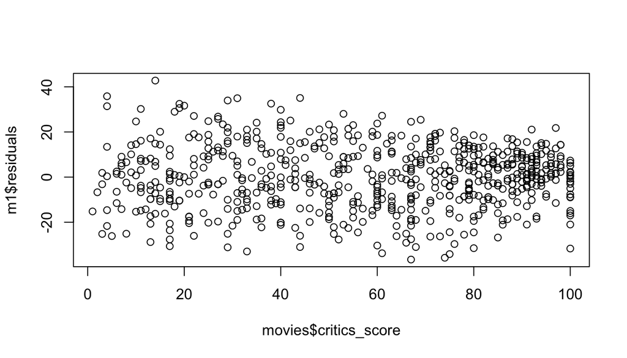

```r
plot (m1$residuals ~ movies$critics_score)
```

2. Check for nearly normal residuals with mean 0. Residuals do seem normally distributed at 0 with only a slight skew to the right. Condition is met.

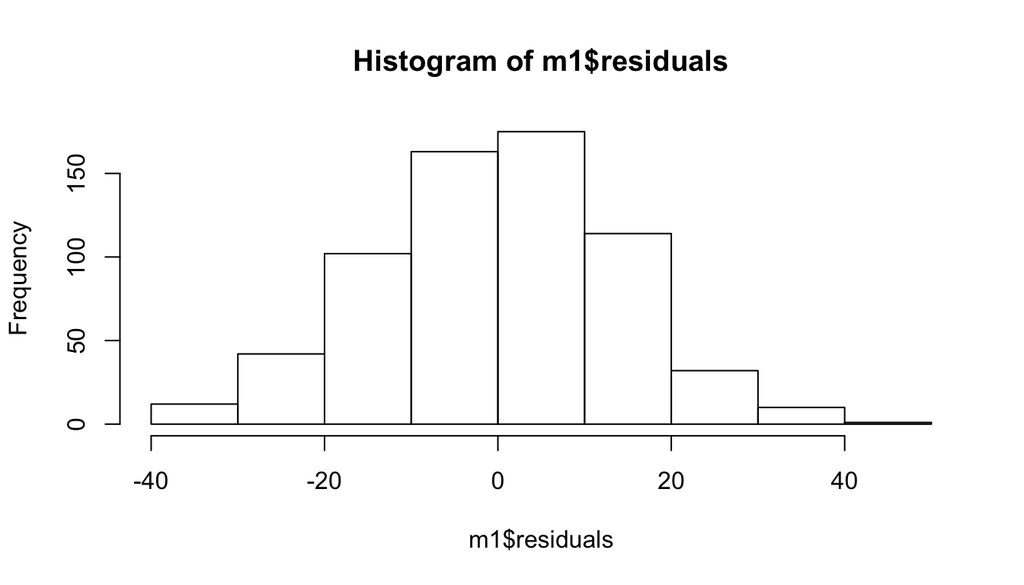

```r
hist (m1$residuals)
```

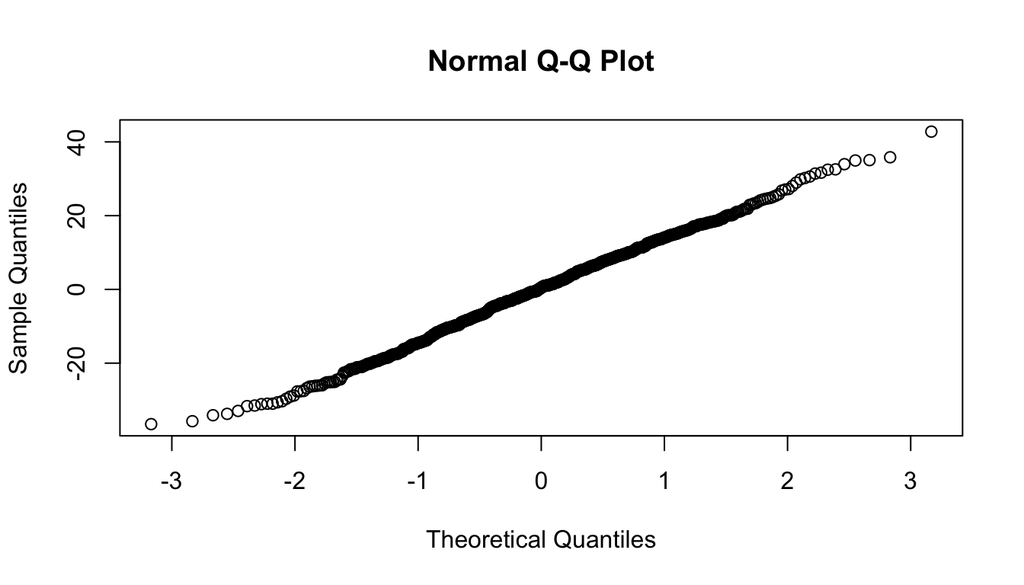

```r
qqnorm(m1$residuals)
```

3. Check for constant variability of residuals. Vairance is a constant at high level but does seem narrower at higher score levels. Hence the condition is generally met but does show some heteroscedasticity at high scores.

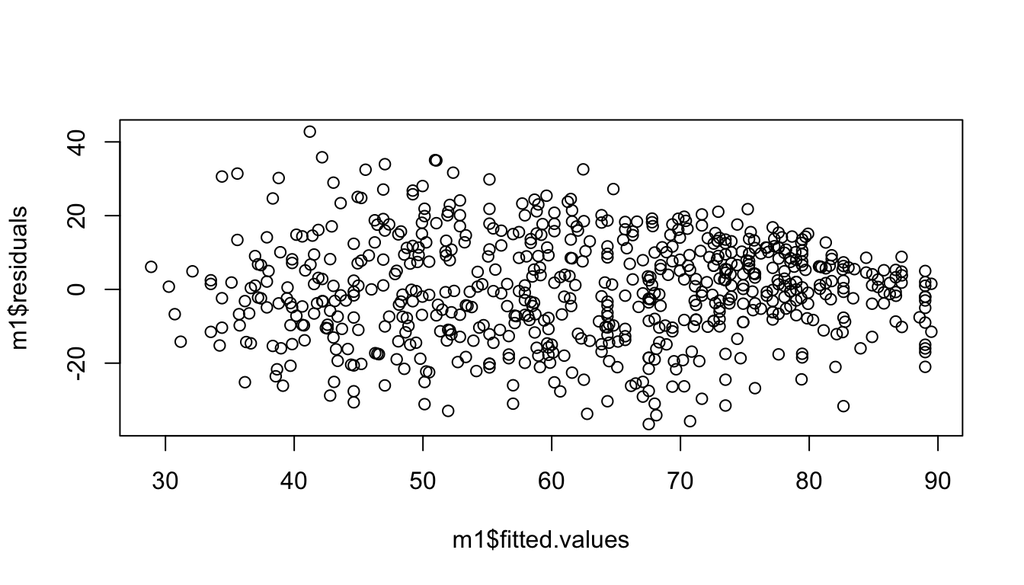

```r
plot(m1$residuals ~ m1$fitted.values)
```

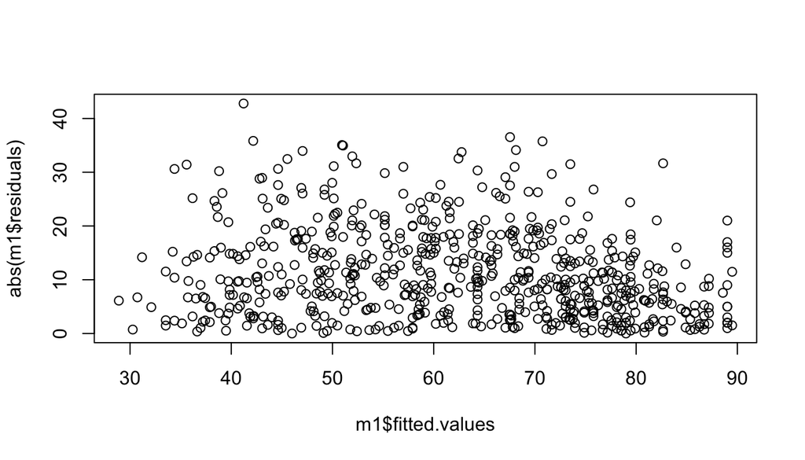

```r
plot(abs(m1$residuals) ~ m1$fitted.values)
```

## Part 5: Prediction

```r
cloverfield <- data.frame (critics_score = 90, genre = "Horror")
predict (m1, cloverfield, interval = "confidence")
```

```
##        fit      lwr      upr
## 1 66.92668 60.86557 72.98779
```

## Part 6: Conclusion

I have learned that critic rating is the primary statistically significant predictor variable to audience score. Genre is a secondary contributor with specific genres more statistically significant. Conditions for multiple regression are generally met with a small amount of heteroscedasticity at high audience scores.

The model could have higher predictive value with a randomly generated observational study.